# STAT167 HW2 - Spring 2021

### (d) [10pt] `stat` functions

Most `geom` functions and `stat` functions come in pairs that are almost always used in concert.

- every `geom` has a default `stat`
- every `stat` has a default `geom`

Look up the default `stat` functions for the `geom` functions listed in the following table. Also, find out the variables computed by the default `stat` function (See the **Computed variables** section in the documentation page).

**ANSWER (in the table)**

[output not shown]

Some `geom` function has stat = “identity” as the default. What does that mean?

**ANSWER:** we use "identity if we want the heights of the bars to represent values in the data.

**Notes**: Table formatting are sometimes tricky using R Markdown. [Table Generator](http://www.tablesgenerator.com/markdown_tables) is a handy tool if you need to make tables in the future.

### (e) [10pt] Position adjustment options for `geom_bar()`

Choose two categorical variables from the `mpg` data set and use them to illustrate the following four position adjustment options for `geom_bar()`:

**ANSWER:**

```r
library(gridExtra) # load gridextra library
```

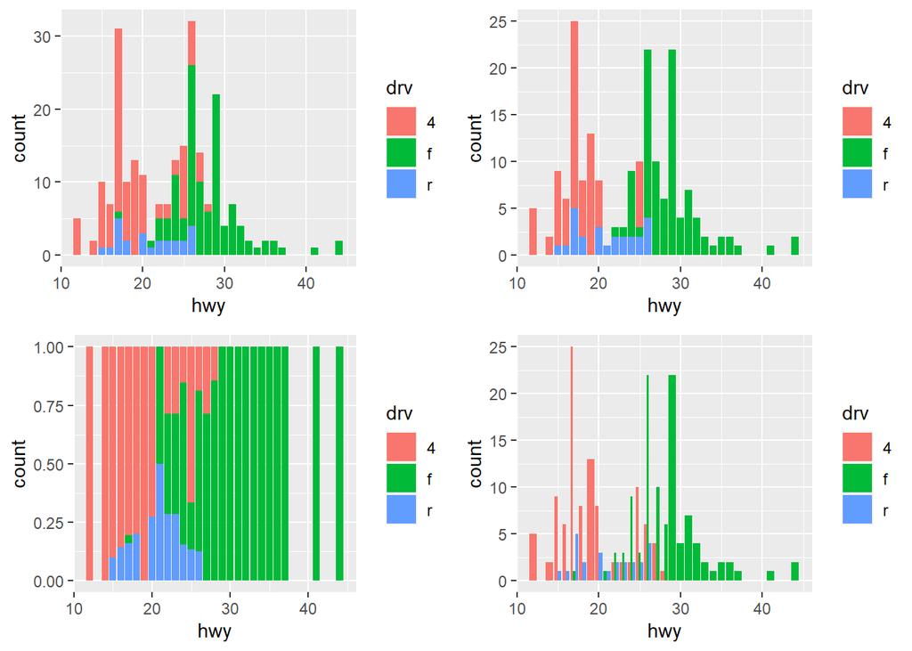

```r
gg <- ggplot(data = mpg, # plot mpg data, with x = hwy and fill by drive
             mapping = aes(x = hwy, fill = drv))
plot1 <- gg + geom_bar(position="stack") # use stacks position
plot2 <- gg + geom_bar(position="identity") # use identity position
plot3 <- gg + geom_bar(position="fill") # use fill position
plot4 <- gg + geom_bar(position="dodge") # use dodge position
grid.arrange(plot1, plot2, plot3, plot4, ncol=2) # arrange grid with created plots in two columns
```

Which position option do you like most? What conclusions can you draw from your plot?

**ANSWER:** I like the identity option the most. Based of my plot, I can conclude that cars with forward drive have the best highway mileage.

## **Question 2 [40pt] Visualization the `quakes` data set**

Recall that the `quakes` data set contain the locations of 1000 seismic events of MB > 4.0. The events occurred in a cube near Fiji since 1964.

```r
library(datasets) # load datasets library
?quakes # documentation for quakes
```

```r
class(quakes)
## [1] "data.frame"
head(quakes, n=5) # print first 5 rows of quakes
##      lat   long depth mag stations
## 1 -20.42 181.62   562 4.8       41
## 2 -20.62 181.03   650 4.2       15
## 3 -26.00 184.10    42 5.4       43
## 4 -17.97 181.66   626 4.1       19
## 5 -20.42 181.96   649 4.0       11
dim(quakes)  # dimension of the table
## [1] 1000    5
names(quakes)  # list the variables in quakes
## [1] "lat"      "long"     "depth"    "mag"      "stations"
str(quakes)  # list the structures in quakes
## 'data.frame':    1000 obs. of  5 variables:
##  $ lat     : num  -20.4 -20.6 -26 -18 -20.4 ...
##  $ long    : num  182 181 184 182 182 ...
##  $ depth   : int  562 650 42 626 649 195 82 194 211 622 ...
##  $ mag     : num  4.8 4.2 5.4 4.1 4 4 4.8 4.4 4.7 4.3 ...
##  $ stations: int  41 15 43 19 11 12 43 15 35 19 ...
glimpse(quakes) # get a glimpse of the quakes data
## Rows: 1,000
## Columns: 5
## $ lat      <dbl> -20.42, -20.62, -26.00, -17.97, -20.42, -19.68, -11.70, -2...
## $ long     <dbl> 181.62, 181.03, 184.10, 181.66, 181.96, 184.31, 166.10, 18...
## $ depth    <int> 562, 650, 42, 626, 649, 195, 82, 194, 211, 622, 583, 249, ...
## $ mag      <dbl> 4.8, 4.2, 5.4, 4.1, 4.0, 4.0, 4.8, 4.4, 4.7, 4.3, 4.4, 4.6...
## $ stations <int> 41, 15, 43, 19, 11, 12, 43, 15, 35, 19, 13, 16, 19, 10, 94...
```

### (a) [30pt] Re-plotting the distribution of earthquake magnitudes.

In Homework 1, Question 1(a), you’ve plotted the distribution of the earthquake magnitudes using R base graphics. This week, write your own `ggplot2` code to reproduce the following four subfigures in a 2-by-2 layout.

- subfigure #1: plot a density histogram of the earthquake magnitudes, and then plot the estimated probability density curve in red color in the same plot
- subfigure #2: plot a horizontal boxplot of the earthquake magnitudes
- subfigure #3: plot the empirical cdf of the earthquake magnitudes
- subfigure #4: make a Q-Q plot to compare the observed earthquake magnitudes distribution with the Normal distribution. Add a *thick* Q-Q line in blue color.

**Hints**:

- In the lecture notes, we used the `grid.arrange()` function from the `gridExtra` package (see [this vignette](https://cran.r-project.org/web/packages/gridExtra/vignettes/arrangeGrob.html)) to layout multiple plots in a single figure. For alternative options, please refer to [this post](https://cran.r-project.org/web/packages/egg/vignettes/Ecosystem.html).
- Check out [the `geom_histogram()` function](http://ggplot2.tidyverse.org/reference/geom_histogram.html) for plotting the **density** histogram.
- Check out [the `stat_ecdf()` function](http://ggplot2.tidyverse.org/reference/stat_ecdf.html) for plotting the empirical distribution.
- Check out [the `stat_qq()` and `stat_qq_line()` functions](https://ggplot2.tidyverse.org/reference/geom_qq.html) for plotting the Q-Q plot and Q-Q line.

**_YOUR_ANSWER**

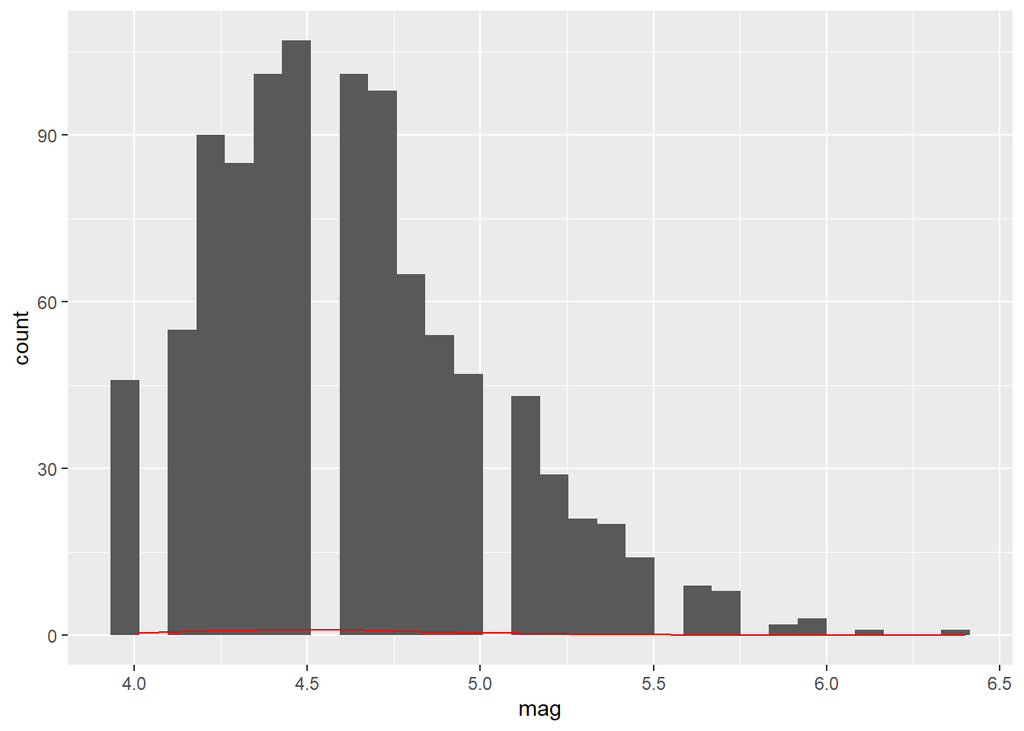

```r
gg1 <- ggplot(data = quakes, aes(x = mag))  # plot quakes data qith x = mag
plotA <- gg1 + # plot gg1
  geom_histogram() + # make histogram
  geom_density(aes(x = mag), color = "red") # make density curve with red color
plotA # print to check
```

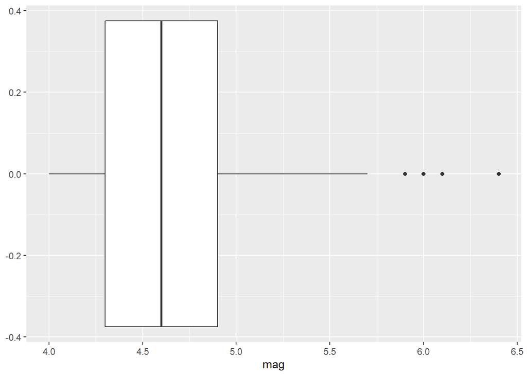

```r
plotB <- gg1 + # plot gg1
  geom_boxplot() # plot a boxplot
plotB# print to check
```

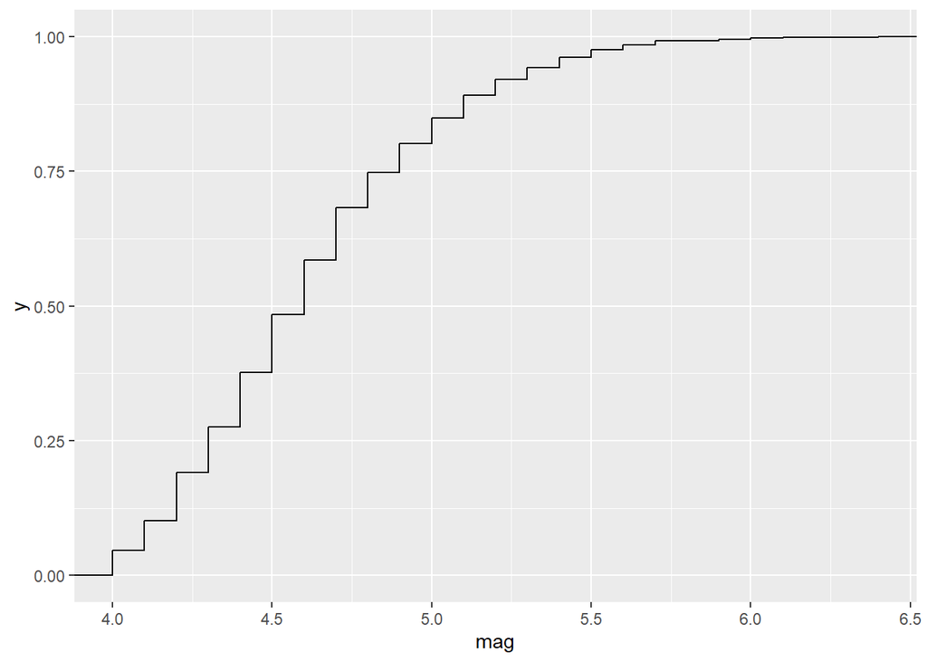

```r
plotC <- gg1 + # print gg1
  stat_ecdf() # plot ecdf
plotC # print to check
```

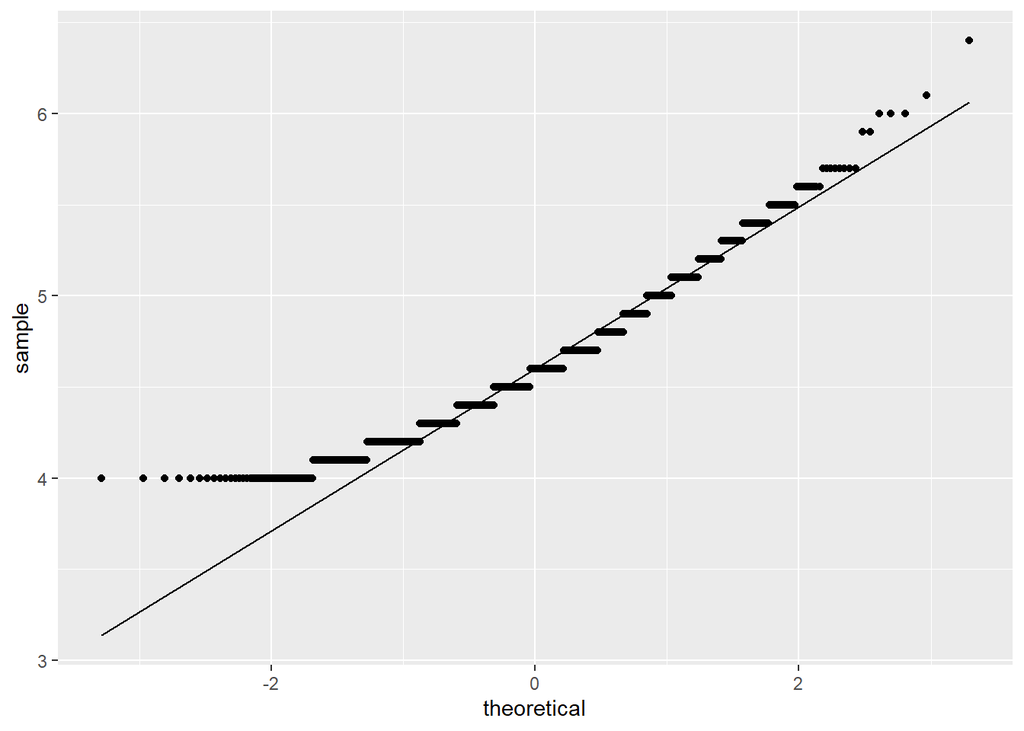

```r
plotD <- ggplot(quakes, aes(sample = mag))+ # make plot of quakes with mpg values
  stat_qq() + # make a qq plot
  geom_qq_line() # plot a qqline
plotD # print to check
```

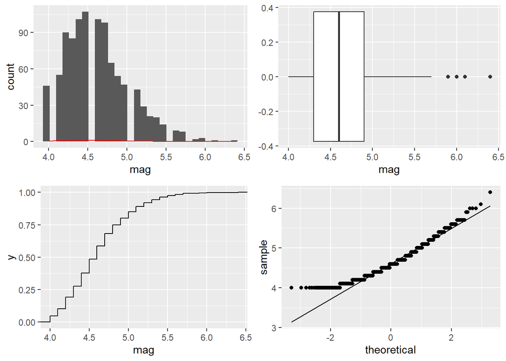

```r
grid.arrange(plotA, plotB, plotC, plotD, ncol = 2) # arrange plots over two columns
```

### (b) [10pt] Earthquake location map

Make a scatter plot of the earthquake locations. Use `long` as the x-axis and `lat` as the y-axis. Map `mag` to the size aesthetic and `depth` to the color aesthetic.

[**Extra credit 20pt**] If you can plot earthquakes point on top of a map layer, you will earn extra points!

**ANSWER:**

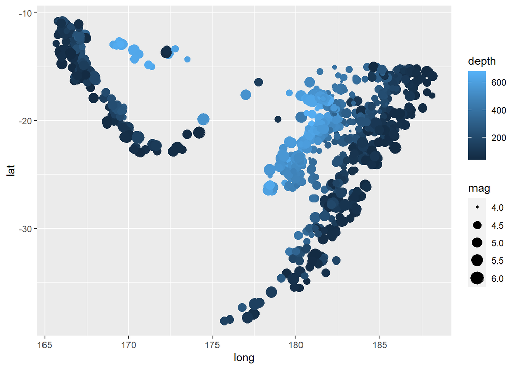

```r
ggplot() + # ggplot
  geom_point(data = quakes, mapping = aes(x = long, y = lat, size = mag, color = depth)) # plot points from quakes data with x = long, y = lat, size = mag, and color by depth
```